# Reproducible Research: Peer Assessment 1

## Download and Prepare Data for Analysis

Step 1. Download the Personal Activity Monitoring data.  
This assignment makes use of data from a personal activity monitoring device. This device collects data at 5 minute intervals through out the day. The data consists of two months of data from an anonymous individual collected during the months of October and November, 2012 and includes the number of steps taken in 5 minute intervals each day.

The variables included in this dataset are:

- **steps:** Number of steps taking in a 5-minute interval (missing values are coded as NA)
- **date:** The date on which the measurement was taken in YYYY-MM-DD format
- **interval:** Identifier for the 5-minute interval in which measurement was taken

The dataset is stored in a comma-separated-value (CSV) file and there are a total of 17,568 observations in this dataset.

Code to download data (I’m not evaluting this code block because the file has already been downloaded):

```r
URL <- "https://d396qusza40orc.cloudfront.net/repdata%2Fdata%2Factivity.zip"
download.file(URL, destfile = "./activity.zip")
```

Step 2. Read data into a data frame

```r
unzip("./activity.zip", exdir="./data")
PersonalActivityData <- read.csv("./data/activity.csv")
```

## What is mean total number of steps taken per day?

Sum up steps by day, create histogram, and then calculate mean and median. I chose to use gglot to gain some experiencee with a different plotting system.

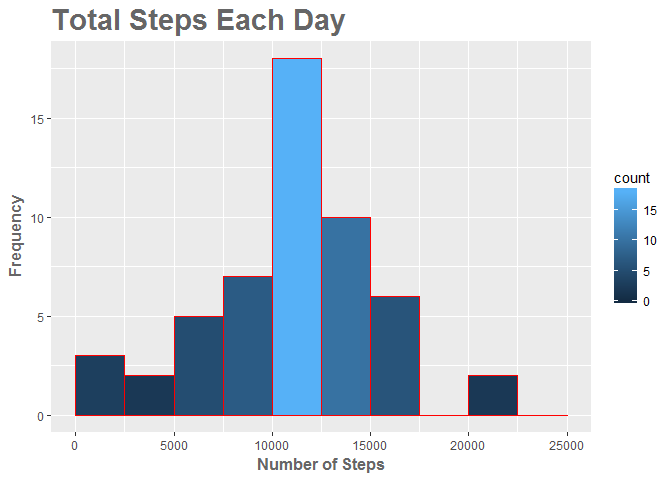

```r
StepsByDay <- aggregate(steps ~ date, PersonalActivityData, sum)


ggplot(data=StepsByDay, aes(StepsByDay$steps)) +
  geom_histogram(breaks=seq(0, 25000, by =2500),
                 col="red",
                 aes(fill=..count..)) +
  ggtitle("Total Steps Each Day") +
  labs(x="Number of Steps",y="Frequency") +
  theme(plot.title = element_text(color="#666666", face="bold", size=22, hjust=0)) +
  theme(axis.title = element_text(color="#666666", face="bold", size=12))
```

```r
# Set options to print numbers not in scientific notation
options("scipen"=100, "digits"=4)

rmean <- mean(StepsByDay$steps)
rmedian <- median(StepsByDay$steps)
```

The `mean` is 10766.1887  
The `median` is 10765.

## What is the average daily activity pattern?

- Calculate average steps for each interval for all days.
- Plot the Average Number Steps per Day by Interval.
- Find interval with most average steps.

[figure not shown]

```r
StepsByInterval <- aggregate(steps ~ interval, PersonalActivityData, mean)

maxsteps <- StepsByInterval[which.max(StepsByInterval$steps),1]

ggplot(StepsByInterval, aes(x=interval, y=steps)) +
  geom_line() +
  ggtitle("Average Number of Steps per Day by Interval") +
  labs(x="Interval",y="Number of Steps")+
  theme(plot.title = element_text(color="#666666", face="bold", size=18, hjust=0)) +
  theme(axis.title = element_text(color="#666666", face="bold", size=12)) +
geom_vline(color="blue", xintercept = maxsteps)
```

The 5-minute interval, on average across all the days in the data set, containing the maximum number of steps is 835.